# Данные о численности населения мира

https://www.kaggle.com/datasets/sazidthe1/world-population-data?select=world_population_data.csv

**О наборе данных** Контекст

**Содержание**

Этот набор данных предоставляет исчерпывающие исторические данные о численности населения для стран и территорий во всем мире, предлагая представление о различных параметрах, таких как размер площади, континент, темпы роста населения, рейтинги и процент населения мира. С 1970 по 2023 год он включает в себя данные о численности населения за разные годы, что позволяет детально изучить демографические тенденции и изменения с течением времени.

**Набор данных**

Этот набор данных, структурированный с тщательной детализацией, предлагает широкий спектр информации в формате, способствующем анализу и исследованию. Благодаря таким параметрам, как население по годам, рейтинг стран, географические детали и темпы роста, он служит ценным ресурсом для исследователей, политиков и аналитиков. Кроме того, включение темпов роста и процентов населения мира дает четкое понимание того, как страны вносят свой вклад в глобальные демографические сдвиги.

Этот набор данных бесценен для тех, кто заинтересован в понимании исторических тенденций в области народонаселения, прогнозировании будущих демографических моделей и проведении углубленного анализа для информирования политики в различных секторах, таких как экономика, городское планирование, общественное здравоохранение и многое другое.

**Структура**

Этот набор данных, охватывающий период с 1970 по 2023 год, включает в себя следующие столбцы:

**Имя Столбца описание**

Rank Ранг по численности населения

CCA3 3-значный код страны/территории

Country Название страны

Continent Название континента

2023 Population Население страны в 2023 году

2022 Population Население страны в 2022 году

2020 Population Население страны в 2020 году

2015 Population Население страны в 2015 году

2010 Population Население страны в 2010 году

2000 Population Население страны в 2000 году

1990 Population Население страны в 1990 году

1980 Population Население страны в 1980 году

1970 Population Население страны в 1970 году

Area (km²) Размер территории страны/территории в квадратных километрах

Density (km²) Плотность населения на квадратный километр

Growth Rate Темпы роста населения по странам

World Population Percentage Процент населения по каждой стране

```python
import pandas as pd
import seaborn as sns
import matplotlib.pyplot as plt
import plotly.express as px
from matplotlib.ticker import MultipleLocator
```

```python
# переменные для размеров графиков

a = 20
```

```python
# Загрузка данных из CSV файла в датафрейм
file_path = '1_Данные_о_численности_населения_мира.csv'
world_population_data = pd.read_csv(file_path)

world_population_data.head(1000000)
```

|  | rank | cca3 | country | continent | 2023 population | 2022 population | 2020 population | 2015 population | 2010 population | 2000 population | 1990 population | 1980 population | 1970 population | area (km²) | density (km²) | growth rate | world percentage |
| --- | --- | --- | --- | --- | --- | --- | --- | --- | --- | --- | --- | --- | --- | --- | --- | --- | --- |
| 0 | 1 | IND | India | Asia | 1428627663 | 1417173173 | 1396387127 | 1322866505 | 1240613620 | 1059633675 | 870452165 | 696828385 | 557501301 | 3287590.00 | 481 | 0.81% | 17.85% |
| 1 | 2 | CHN | China | Asia | 1425671352 | 1425887337 | 1424929781 | 1393715448 | 1348191368 | 1264099069 | 1153704252 | 982372466 | 822534450 | 9706961.00 | 151 | -0.02% | 17.81% |
| 2 | 3 | USA | United States | North America | 339996563 | 338289857 | 335942003 | 324607776 | 311182845 | 282398554 | 248083732 | 223140018 | 200328340 | 9372610.00 | 37 | 0.50% | 4.25% |
| 3 | 4 | IDN | Indonesia | Asia | 277534122 | 275501339 | 271857970 | 259091970 | 244016173 | 214072421 | 182159874 | 148177096 | 115228394 | 1904569.00 | 148 | 0.74% | 3.47% |
| 4 | 5 | PAK | Pakistan | Asia | 240485658 | 235824862 | 227196741 | 210969298 | 194454498 | 154369924 | 115414069 | 80624057 | 59290872 | 881912.00 | 312 | 1.98% | 3.00% |
| ... | ... | ... | ... | ... | ... | ... | ... | ... | ... | ... | ... | ... | ... | ... | ... | ... | ... |
| 229 | 230 | MSR | Montserrat | North America | 4386 | 4390 | 4500 | 5059 | 4938 | 5138 | 10805 | 11452 | 11402 | 102.00 | 43 | -0.09% | 0.00% |
| 230 | 231 | FLK | Falkland Islands | South America | 3791 | 3780 | 3747 | 3408 | 3187 | 3080 | 2332 | 2240 | 2274 | 12173.00 | 0 | 0.29% | 0.00% |
| 231 | 232 | NIU | Niue | Oceania | 1935 | 1934 | 1942 | 1847 | 1812 | 2074 | 2533 | 3637 | 5185 | 261.00 | 7 | 0.05% | 0.00% |
| 232 | 233 | TKL | Tokelau | Oceania | 1893 | 1871 | 1827 | 1454 | 1367 | 1666 | 1669 | 1647 | 1714 | 12.00 | 189 | 1.18% | 0.00% |
| 233 | 234 | VAT | Vatican City | Europe | 518 | 510 | 520 | 564 | 596 | 651 | 700 | 733 | 752 | 0.44 | 1177 | 1.57% | 0.00% |

234 rows × 17 columns

```python
world_population_data.describe()
```

|  | rank | 2023 population | 2022 population | 2020 population | 2015 population | 2010 population | 2000 population | 1990 population | 1980 population | 1970 population | area (km²) | density (km²) |
| --- | --- | --- | --- | --- | --- | --- | --- | --- | --- | --- | --- | --- |
| count | 234.000000 | 2.340000e+02 | 2.340000e+02 | 2.340000e+02 | 2.340000e+02 | 2.340000e+02 | 2.340000e+02 | 2.340000e+02 | 2.340000e+02 | 2.340000e+02 | 2.340000e+02 | 234.000000 |
| mean | 117.500000 | 3.437442e+07 | 3.407441e+07 | 3.350107e+07 | 3.172996e+07 | 2.984524e+07 | 2.626947e+07 | 2.271022e+07 | 1.898462e+07 | 1.578691e+07 | 5.814500e+05 | 451.282051 |
| std | 67.694165 | 1.373864e+08 | 1.367664e+08 | 1.355899e+08 | 1.304050e+08 | 1.242185e+08 | 1.116982e+08 | 9.783217e+07 | 8.178519e+07 | 6.779509e+07 | 1.761841e+06 | 1979.398922 |
| min | 1.000000 | 5.180000e+02 | 5.100000e+02 | 5.200000e+02 | 5.640000e+02 | 5.960000e+02 | 6.510000e+02 | 7.000000e+02 | 7.330000e+02 | 7.520000e+02 | 4.400000e-01 | 0.000000 |
| 25% | 59.250000 | 4.225982e+05 | 4.197385e+05 | 4.152845e+05 | 4.046760e+05 | 3.931490e+05 | 3.272420e+05 | 2.641158e+05 | 2.296142e+05 | 1.559970e+05 | 2.650000e+03 | 39.500000 |
| 50% | 117.500000 | 5.643895e+06 | 5.559944e+06 | 5.493074e+06 | 5.307400e+06 | 4.942770e+06 | 4.292907e+06 | 3.825410e+06 | 3.141146e+06 | 2.604830e+06 | 8.119950e+04 | 97.500000 |
| 75% | 175.750000 | 2.324537e+07 | 2.247650e+07 | 2.144798e+07 | 1.973085e+07 | 1.915957e+07 | 1.576230e+07 | 1.186923e+07 | 9.826054e+06 | 8.817329e+06 | 4.304258e+05 | 242.750000 |
| max | 234.000000 | 1.428628e+09 | 1.425887e+09 | 1.424930e+09 | 1.393715e+09 | 1.348191e+09 | 1.264099e+09 | 1.153704e+09 | 9.823725e+08 | 8.225344e+08 | 1.709824e+07 | 21403.000000 |

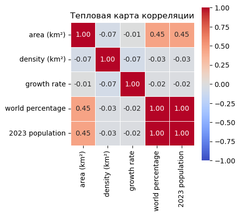

```python
world_population_data_copy = world_population_data.copy(deep=True)

world_population_data_copy['growth rate'] = pd.to_numeric(world_population_data_copy['growth rate'].str.replace('%', ''), errors='coerce')
world_population_data_copy['world percentage'] = pd.to_numeric(world_population_data_copy['world percentage'].str.replace('%', ''), errors='coerce')

# Построение тепловой карты корреляции
correlation_matrix = world_population_data_copy[['area (km²)', 'density (km²)', 'growth rate', 'world percentage', '2023 population']].corr()

plt.figure(figsize=(a * 0.2, a * 0.2))
cmap = sns.color_palette("coolwarm", as_cmap=True)
sns.heatmap(correlation_matrix, annot=True, fmt=".2f", cmap=cmap, vmin=-1, vmax=1, center=0, linewidths=.5, square=True)
plt.title('Тепловая карта корреляции')
plt.show()
```

Прослеживается зависимость размера популяции и процента населения от площади страны.

```python
#world_population_data.dtypes
```

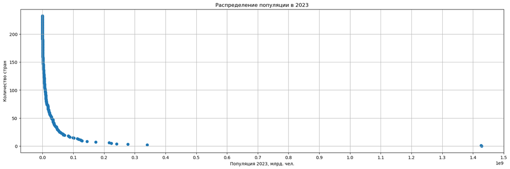

```python
world_population_data_copy = world_population_data.copy(deep = True)

plt.figure(figsize=(a, a * 0.3))
plt.scatter(world_population_data_copy['2023 population'], range(len(world_population_data_copy)))
plt.title('Распределение популяции в 2023')
plt.xlabel('Популяция 2023, млрд. чел.')
plt.ylabel('Количество стран')
plt.grid(True)
plt.gca().xaxis.set_major_locator(MultipleLocator(100000000))
plt.show()
```

В большинстве стран популяция меньше 100 млн. человек.

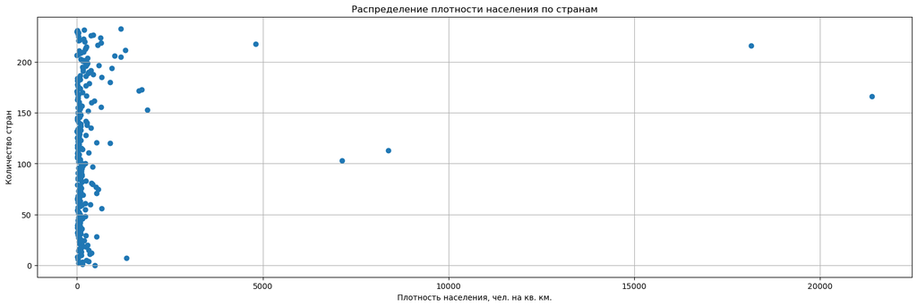

```python
world_population_data_copy = world_population_data.copy(deep = True)

plt.figure(figsize=(a, a * 0.3))
plt.scatter(world_population_data_copy['density (km²)'], range(len(world_population_data_copy)))
plt.title('Распределение плотности населения по странам')
plt.xlabel('Плотность населения, чел. на кв. км.')
plt.ylabel('Количество стран')
plt.grid(True)
#plt.gca().xaxis.set_major_locator(MultipleLocator(100000000))
plt.show()
```

Средняя плотность населения 450 чел. на кв. км.

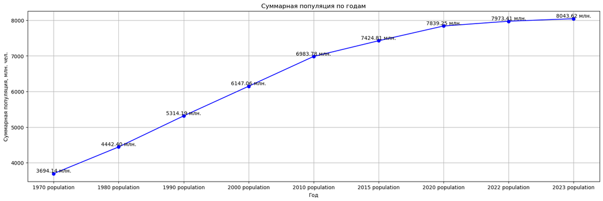

```python
x_columns = ['2023 population', '2022 population', '2020 population', '2015 population', '2010 population', '2000 population', '1990 population', '1980 population', '1970 population']
y_columns = ['2023 population', '2022 population', '2020 population', '2015 population', '2010 population', '2000 population', '1990 population', '1980 population', '1970 population']

# Инвертируйте порядок колонок
x_columns = x_columns[::-1]
y_columns = y_columns[::-1]

# Создайте новый датафрейм с суммарными значениями по выбранным колонкам
sum_df = world_population_data[y_columns].sum()

# Конвертируйте значения в миллионы
sum_df = sum_df / 1e6

# Постройте линейный график
plt.figure(figsize=(a, a * 0.3))
plt.plot(x_columns, sum_df, marker='o', linestyle='-', color='b')

# Добавление значений над точками
for x, y in zip(x_columns, sum_df):
    plt.text(x, y, f'{y:.2f} млн.', ha='center', va='bottom')

plt.title('Суммарная популяция по годам')
plt.xlabel('Год')
plt.ylabel('Суммарная популяция, млн. чел.')
plt.grid(True)
plt.show()
```

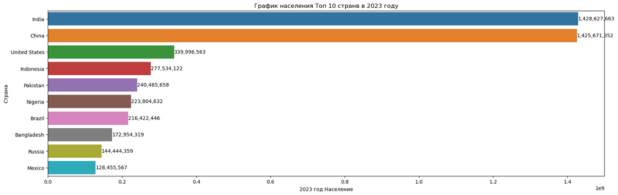

```python
# Установка размера графика
plt.figure(figsize=(a, a * 0.3))

# Выбор только первых 10 стран
top_10_countries = world_population_data.head(10)

# Построение горизонтального столбчатого графика
plot = sns.barplot(x='2023 population', y='country', data=top_10_countries)

# Добавление значений над столбцами
for index, value in enumerate(top_10_countries['2023 population']):
    plot.text(value, index, f'{value:,}', ha='left', va='center', fontsize=10)

# Настройка заголовка и меток осей
plt.title('График населения Топ 10 странв в 2023 году')
plt.xlabel('2023 год Население')
plt.ylabel('Страна')

# Отображение графика
plt.show()
```

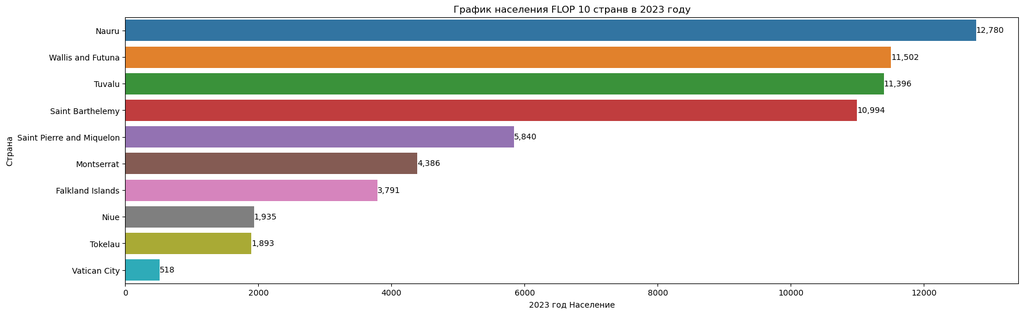

```python
# Установка размера графика
plt.figure(figsize=(a, a * 0.3))

# Выбор только последних 10 стран
bottom_10_countries = world_population_data.tail(10)

# Построение горизонтального столбчатого графика
plot = sns.barplot(x='2023 population', y='country', data=bottom_10_countries)

# Добавление значений над столбцами
for index, value in enumerate(bottom_10_countries['2023 population']):
    plot.text(value, index, f'{value:,}', ha='left', va='center', fontsize=10)

# Настройка заголовка и меток осей
plt.title('График населения FLOP 10 странв в 2023 году')
plt.xlabel('2023 год Население')
plt.ylabel('Страна')

# Отображение графика
plt.show()
```

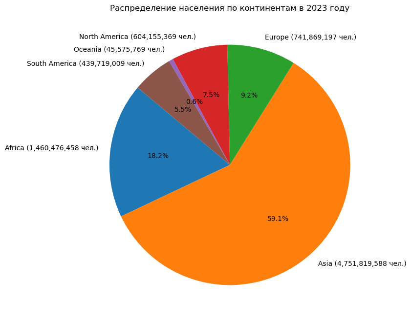

```python
# Группировка данных по континентам и суммирование населения для 2023 года
continent_population = world_population_data.groupby('continent')['2023 population'].sum()

# Создание круговой диаграммы
plt.figure(figsize=(a * 0.5, a * 0.4))
patches, texts, autotexts = plt.pie(continent_population, labels=continent_population.index, autopct='%1.1f%%', startangle=140)

# Добавление аннотаций (количество жителей) на круговую диаграмму
for text, autotext, value in zip(texts, autotexts, continent_population):
    text.set_text(f'{text.get_text()} ({value:,} чел.)')

# Настройка заголовка
plt.title('Распределение населения по континентам в 2023 году')

# Отображение круговой диаграммы
plt.show()
```

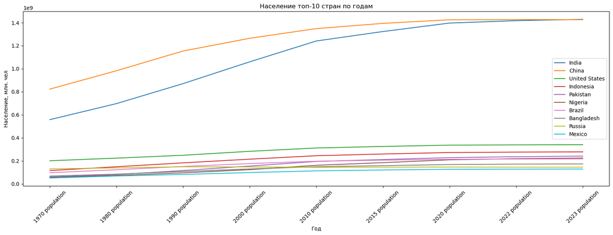

```python
# Выбираем первые 10 стран
top_10_countries = world_population_data.head(10)

# Отсортируем столбцы с годами
sorted_columns = sorted(['2023 population', '2022 population', '2020 population', '2015 population',
                          '2010 population', '2000 population', '1990 population', '1980 population', '1970 population'])

# Строим линейные графики для каждой страны
plt.figure(figsize=(a, a * 0.3))

for index, row in top_10_countries.iterrows():
    country_name = row['country']
    population_data = row[sorted_columns]

    plt.plot(population_data, label=country_name)

# Настройка осей и легенды
plt.xlabel('Год')
plt.ylabel('Население, млн. чел')
plt.title('Население топ-10 стран по годам')
plt.legend()
plt.xticks(rotation=45)  # Поворот названий годов для лучшей читаемости

# Отображение графика
plt.show()
```

```python
# Создаем DataFrame down_Population
down_Population = world_population_data[['rank', 'cca3', 'country', 'continent', '2023 population', '1970 population']].copy()

# Добавляем колонку down_Population как разницу между 2023 population и 1970 population
down_Population['down_Population'] = down_Population['2023 population'] - down_Population['1970 population']

# Сортируем по возрастанию по колонке down_Population
down_Population = down_Population.sort_values(by='down_Population')

# Отфильтровываем значения меньше или равно нулю
down_Population = down_Population[down_Population['down_Population'] <= 0]

# Выводим результат
down_Population.head(1000000)
```

|  | rank | cca3 | country | continent | 2023 population | 1970 population | down_Population |
| --- | --- | --- | --- | --- | --- | --- | --- |
| 40 | 41 | UKR | Ukraine | Europe | 36744634 | 47279086 | -10534452 |
| 109 | 110 | BGR | Bulgaria | Europe | 6687717 | 8582950 | -1895233 |
| 131 | 132 | GEO | Georgia | Asia | 3728282 | 4800426 | -1072144 |
| 136 | 137 | BIH | Bosnia and Herzegovina | Europe | 3210847 | 3815561 | -604714 |
| 150 | 151 | LVA | Latvia | Europe | 1830211 | 2397414 | -567203 |
| 141 | 142 | LTU | Lithuania | Europe | 2718352 | 3210147 | -491795 |
| 129 | 130 | HRV | Croatia | Europe | 4008617 | 4492638 | -484021 |
| 133 | 134 | MDA | Moldova | Europe | 3435931 | 3711140 | -275209 |
| 93 | 94 | HUN | Hungary | Europe | 10156239 | 10315366 | -159127 |
| 104 | 105 | SRB | Serbia | Europe | 7149077 | 7193533 | -44456 |
| 155 | 156 | EST | Estonia | Europe | 1322765 | 1361999 | -39234 |
| 63 | 64 | ROU | Romania | Europe | 19892812 | 19922618 | -29806 |
| 229 | 230 | MSR | Montserrat | North America | 4386 | 11402 | -7016 |
| 222 | 223 | COK | Cook Islands | Oceania | 17044 | 20470 | -3426 |
| 231 | 232 | NIU | Niue | Oceania | 1935 | 5185 | -3250 |
| 233 | 234 | VAT | Vatican City | Europe | 518 | 752 | -234 |

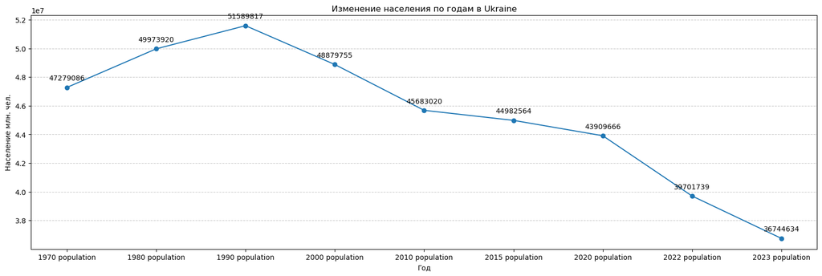

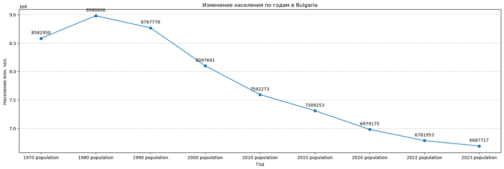

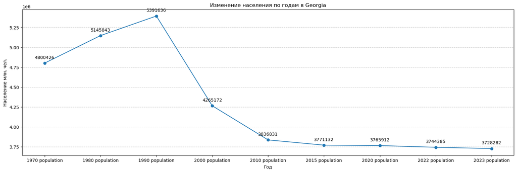

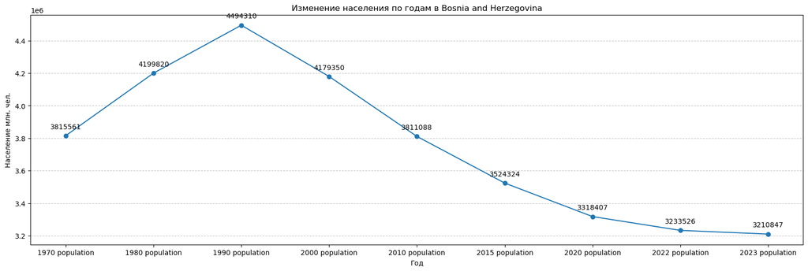

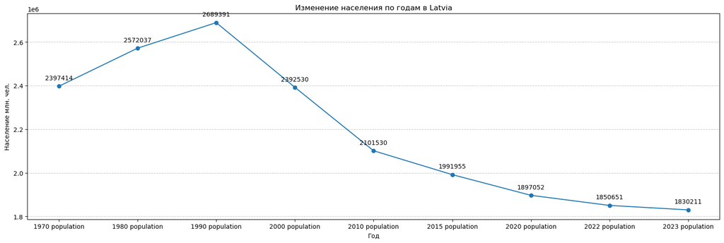

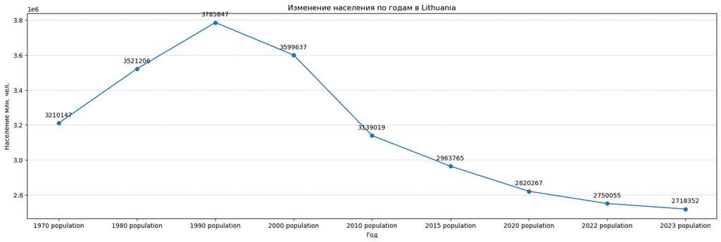

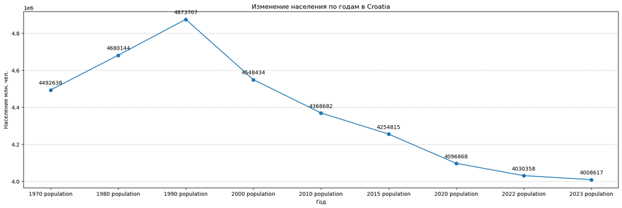

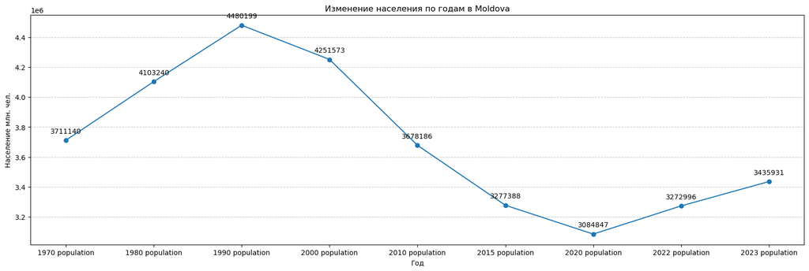

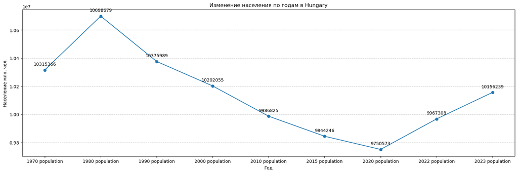

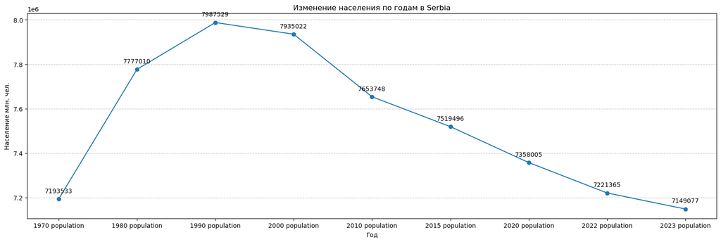

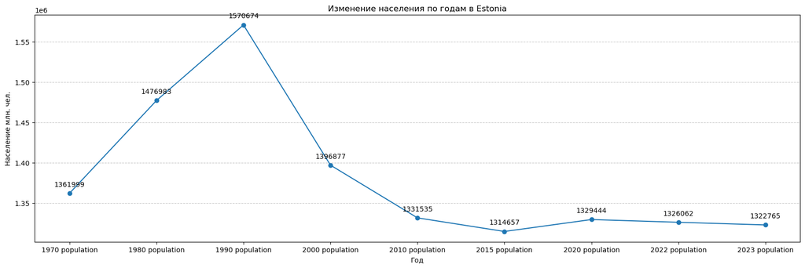

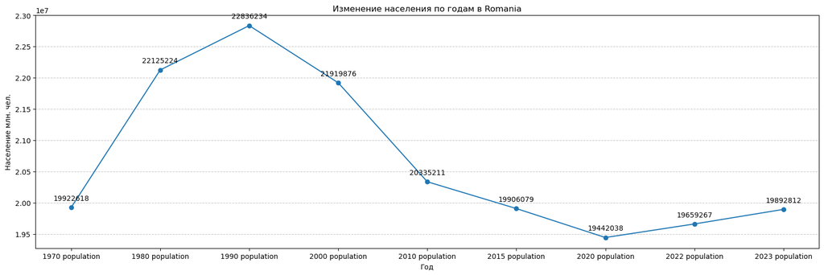

[4 more figures not shown]

```python
# Создаем DataFrame down_Population
down_Population = world_population_data.copy()

# Добавляем колонку down_Population как разницу между 2023 population и 1970 population
down_Population['down_Population'] = down_Population['2023 population'] - down_Population['1970 population']

# Сортируем по возрастанию по колонке down_Population
down_Population = down_Population.sort_values(by='down_Population')

# Отфильтровываем значения меньше или равно нулю
down_Population = down_Population[down_Population['down_Population'] <= 0]

# Определение списка колонок с данными о населении
population_columns = ['2023 population', '2022 population', '2020 population',
                      '2015 population', '2010 population', '2000 population',
                      '1990 population', '1980 population', '1970 population']

# Переворачивание порядка колонок по оси x
population_columns.reverse()

# Построение графиков для каждой страны
for country in down_Population['country'].unique():
    country_data = down_Population[down_Population['country'] == country]

    # Сортировка данных по выбранным годам
    sorted_data = country_data[population_columns]

    # Построение линейного графика
    plt.figure(figsize=(a, a * 0.3))
    plt.plot(sorted_data.columns, sorted_data.iloc[0], marker='o', label=country)

    # Добавление значений к точкам на графике
    for i, txt in enumerate(sorted_data.iloc[0]):
        plt.annotate(txt, (sorted_data.columns[i], sorted_data.iloc[0, i]), textcoords="offset points", xytext=(0,10), ha='center')

    plt.title(f'Изменение населения по годам в {country}')
    plt.xlabel('Год')
    plt.ylabel('Население млн. чел.')

    # Добавление горизонтальных линий сетки
    plt.grid(axis='y', linestyle='--', alpha=0.7)

    plt.show()
```

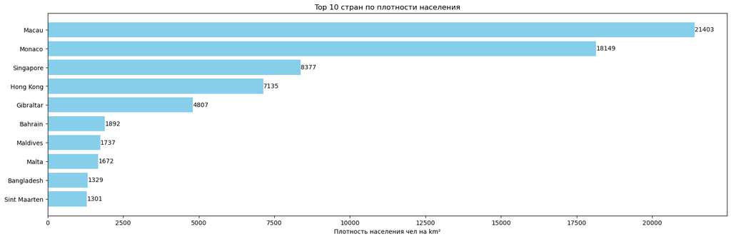

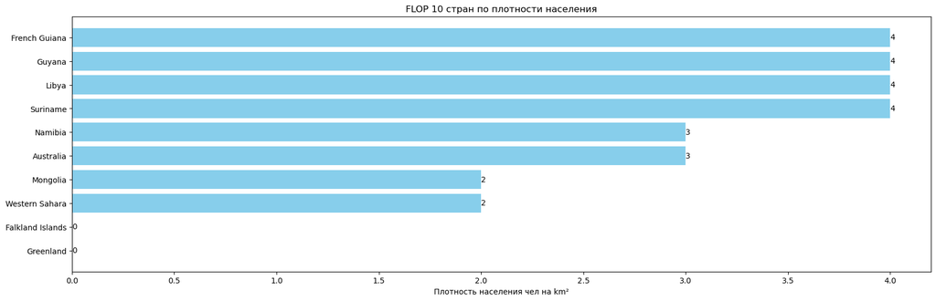

```python
# Сортировка по убыванию density (km²)
sorted_data = world_population_data.sort_values(by='density (km²)', ascending=False).copy()

# Построение горизонтальных столбчатых диаграмм для первых 10 стран
plt.figure(figsize=(a, a * 0.3))
bars = plt.barh(sorted_data['country'].head(10), sorted_data['density (km²)'].head(10), color='skyblue')
plt.xlabel('Плотность населения чел на km²')
plt.title('Top 10 стран по плотности населения')
plt.gca().invert_yaxis()  # чтобы страны были в порядке убывания

# Добавление значений на столбцы
for bar in bars:
    yval = bar.get_width()  # теперь берем значение из ширины столбца
    plt.text(yval, bar.get_y() + bar.get_height()/2, round(yval, 2), ha='left', va='center')

plt.show()

# Построение горизонтальных столбчатых диаграмм для последних 10 стран
plt.figure(figsize=(a, a * 0.3))
bars_bottom = plt.barh(sorted_data['country'].tail(10), sorted_data['density (km²)'].tail(10), color='skyblue')
plt.xlabel('Плотность населения чел на km²')
plt.title('FLOP 10 стран по плотности населения')
plt.gca().invert_yaxis()  # чтобы страны были в порядке убывания

# Добавление значений на столбцы
for bar in bars_bottom:
    yval = bar.get_width()  # теперь берем значение из ширины столбца
    plt.text(yval, bar.get_y() + bar.get_height()/2, round(yval, 2), ha='left', va='center')

plt.show()
```

```python
continent_metriks = world_population_data.copy(deep=True)

pivot_table = pd.pivot_table(continent_metriks, values=['2023 population', 'area (km²)'], index='continent', aggfunc='sum')

pivot_table['density (km²)'] = pivot_table['2023 population'] / pivot_table['area (km²)']

pivot_table = pivot_table.reset_index()

# Сортировка по увеличению '2023 population'
pivot_table = pivot_table.sort_values(by='2023 population', ascending=True)

# Выводим DataFrame
pivot_table.head(1000000)
```

|  | continent | 2023 population | area (km²) | density (km²) |
| --- | --- | --- | --- | --- |
| 4 | Oceania | 45575769 | 8515218.00 | 5.352273 |
| 5 | South America | 439719009 | 17833382.00 | 24.657073 |
| 3 | North America | 604155369 | 24244178.00 | 24.919606 |
| 2 | Europe | 741869197 | 23010411.26 | 32.240588 |
| 0 | Africa | 1460476458 | 30317963.00 | 48.171985 |
| 1 | Asia | 4751819588 | 32138143.90 | 147.856068 |

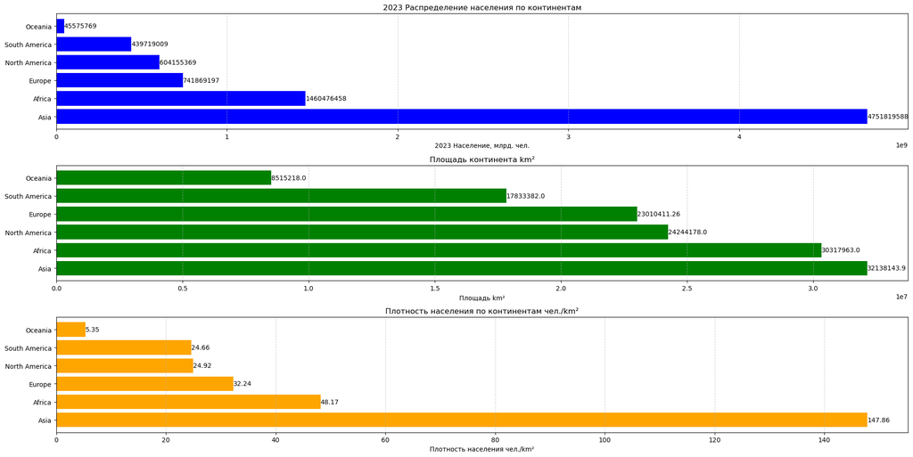

```python
# Сортируем DataFrame по каждому столбцу
sorted_by_population = pivot_table.sort_values(by='2023 population', ascending=False)
sorted_by_area = pivot_table.sort_values(by='area (km²)', ascending=False)
sorted_by_density = pivot_table.sort_values(by='density (km²)', ascending=False)

# Создаем три горизонтальных столбчатых графика
plt.figure(figsize=(a , a * 0.5))

# График для '2023 population'
plt.subplot(3, 1, 1)
bars_population = plt.barh(sorted_by_population['continent'], sorted_by_population['2023 population'], color='blue')
plt.xlabel('2023 Население, млрд. чел.')
plt.title('2023 Распределение населения по континентам')

# Добавляем значения внутри столбцов
for bar in bars_population:
    yval = bar.get_width()
    plt.text(yval, bar.get_y() + bar.get_height()/2, round(yval, 2), ha='left', va='center')

# Добавляем вертикальные линии сетки
plt.grid(axis='x', linestyle='--', alpha=0.6)

# График для 'area (km²)'
plt.subplot(3, 1, 2)
bars_area = plt.barh(sorted_by_area['continent'], sorted_by_area['area (km²)'], color='green')
plt.xlabel('Площадь km²')
plt.title('Площадь континента km²')

# Добавляем значения внутри столбцов
for bar in bars_area:
    yval = bar.get_width()
    plt.text(yval, bar.get_y() + bar.get_height()/2, round(yval, 2), ha='left', va='center')

# Добавляем вертикальные линии сетки
plt.grid(axis='x', linestyle='--', alpha=0.6)

# График для 'density (km²)'
plt.subplot(3, 1, 3)
bars_density = plt.barh(sorted_by_density['continent'], sorted_by_density['density (km²)'], color='orange')
plt.xlabel('Плотность населения чел./km²')
plt.title('Плотность населения по континентам чел./km²')

# Добавляем значения внутри столбцов
for bar in bars_density:
    yval = bar.get_width()
    plt.text(yval, bar.get_y() + bar.get_height()/2, round(yval, 2), ha='left', va='center')

# Добавляем вертикальные линии сетки
plt.grid(axis='x', linestyle='--', alpha=0.6)

plt.tight_layout()
plt.show()
```

```python
fig = px.choropleth(
    world_population_data,
    locations="cca3",
    color="2023 population",
    hover_name="country",
    color_continuous_scale="RdYlGn",  # Красно-зелёная цветовая схема
    #color_continuous_scale=px.colors.sequential.Plasma,
    title="Численность населения по странам в 2023 году",
    labels={"2023 population": "Население 2023"},
    projection="natural earth"
)

# Увеличение размера карты
fig.update_layout(width=1000, height=500)

# Отображение карты
fig.show()
```

[interactive chart not shown]